# Task 2

Ã˜rjan Mikal Antonsen

25 september 2018

## Importerer fil 95274 som viser kapasitetsbegrensning og priser for hotell og overnatting i fylker.

Henter ut datasettet fra county og fjerner pris per rom, endrer også måned til month pga å.

Separerer M ifra date slik at year og month blir separert, setter deretter sammen slik at M forsvinner.

GÃ¥r fra long til wide

Fikser pÃ¥ dato

Selekterer slik at vi stÃ¥r igjen med dato og pris per rom, og fjerner priser med verdi 0

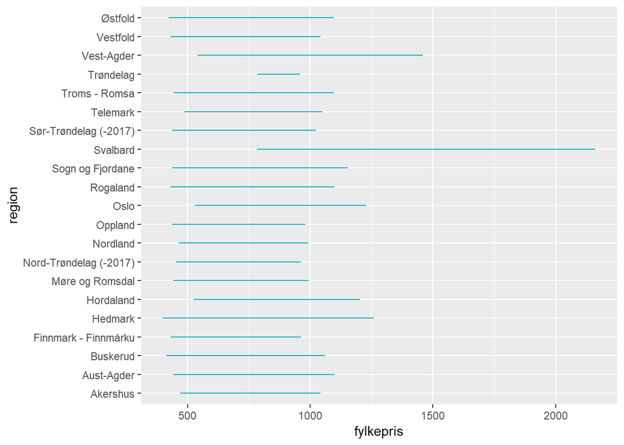

Svalbard er over gjennomsnittet dyrere enn de andre fylkene.

## Importerer fil 95276 som viser kap.begrensning og priser for hoteller og overnatting over hele landet.

Henter ut datasettet fra country og fjerner pris per rom. Gjør måned også om til date.

Igjen separer man slik at M forsvinner i fra dato. Legger sammen dato igjen etterpÃ¥

GÃ¥r ifra long til wide

Fikser på dato, har fortsatt value for tid, men siden det bare er 403 kolonner nå trengs den ikke å bli repetert. Bruker derfor nytid.

Selekter ut slik at vi står igjen med pris per rom og dato, fjerner også pris med verdi 0.

Ser også på om alt stemmer med head, tail og glimpse.

```
##           date prisnorge
## 85  1992-01-01       554
## 86  1992-02-01       569
## 87  1992-03-01       581
## 88  1992-04-01       580
## 89  1992-05-01       574
## 90  1992-06-01       540
## 91  1992-07-01       485
## 92  1992-08-01       527
## 93  1992-09-01       587
## 94  1992-10-01       585
## 95  1992-11-01       579
## 96  1992-12-01       589
## 97  1993-01-01       559
## 98  1993-02-01       586
## 99  1993-03-01       572
## 100 1993-04-01       579
## 101 1993-05-01       574
## 102 1993-06-01       547
## 103 1993-07-01       492
## 104 1993-08-01       542
```

```
##           date prisnorge
## 384 2016-12-01       891
## 385 2017-01-01       899
## 386 2017-02-01       931
## 387 2017-03-01       941
## 388 2017-04-01       925
## 389 2017-05-01       970
## 390 2017-06-01       990
## 391 2017-07-01       893
## 392 2017-08-01       945
## 393 2017-09-01       991
## 394 2017-10-01       943
## 395 2017-11-01       968
## 396 2017-12-01       927
## 397 2018-01-01       917
## 398 2018-02-01       946
## 399 2018-03-01       950
## 400 2018-04-01       940
## 401 2018-05-01       957
## 402 2018-06-01      1004
## 403 2018-07-01       926
```

```
## Observations: 319
## Variables: 2
## $ date      <date> 1992-01-01, 1992-02-01, 1992-03-01, 1992-04-01, 199...
## $ prisnorge <dbl> 554, 569, 581, 580, 574, 540, 485, 527, 587, 585, 57...
```

lager en ggplot for pris over hele landet

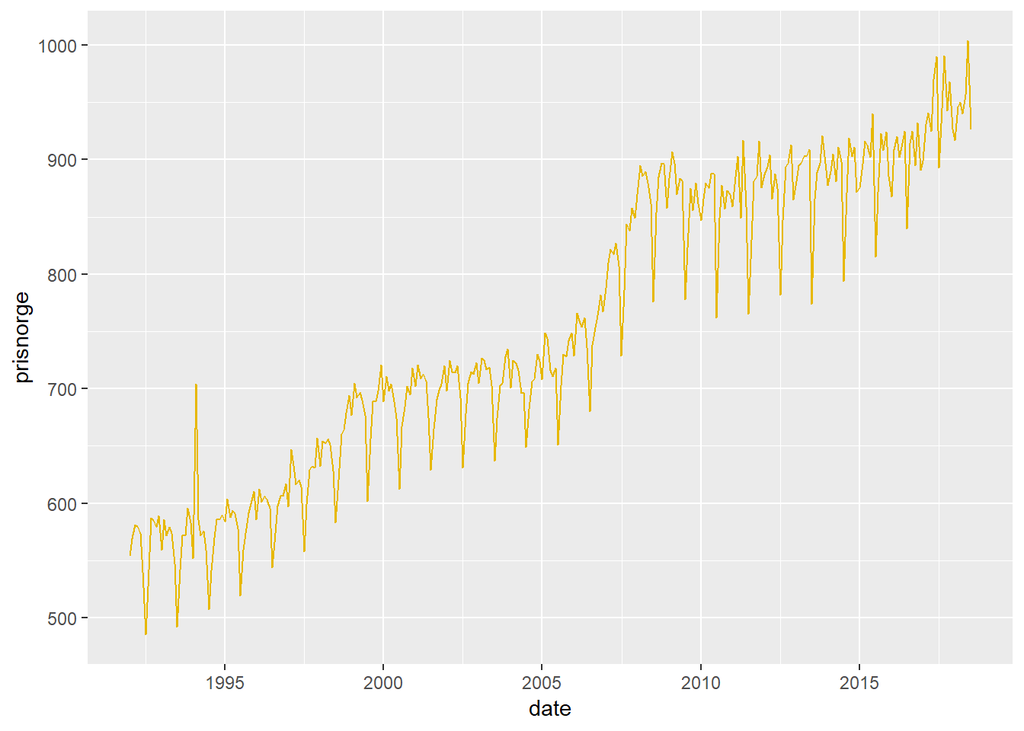

Merger datafilene sammen

GÃ¥r fra wide til long

```
##         date  variable pris
## 1 1992-01-01 fylkepris  628
## 2 1992-02-01 fylkepris  630
## 3 1992-03-01 fylkepris  625
## 4 1992-04-01 fylkepris  671
## 5 1992-05-01 fylkepris  637
## 6 1992-06-01 fylkepris  598
```

lager en samlet plot for hele landet.

[figure not shown]

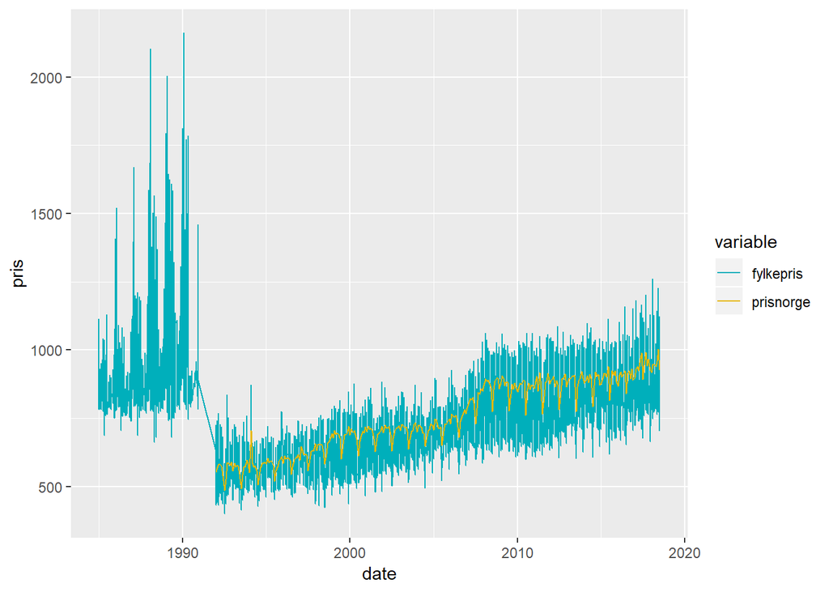